# Project 2: Modeling and Evaluation

CSE6242 - Data and Visual Analytics - Summer 2018 Due: Sunday, July 24, 2018 at 11:59 PM UTC-12:00 on T-Square

Mohitdeep Singh (msingh74)

# Data

We will use the same dataset as Project 1: [`movies_merged`](https://s3.amazonaws.com/content.udacity-data.com/courses/gt-cs6242/project/movies_merged).

# Objective

Your goal in this project is to build a linear regression model that can predict the `Gross` revenue earned by a movie based on other variables. You may use R packages to fit and evaluate a regression model (no need to implement regression yourself). Please stick to linear regression, however.

# Instructions

You should be familiar with using an [RMarkdown](http://rmarkdown.rstudio.com) Notebook by now. Remember that you have to open it in RStudio, and you can run code chunks by pressing *Cmd+Shift+Enter*.

Please complete the tasks below and submit this R Markdown file (as **pr2.Rmd**) containing all completed code chunks and written responses, and a PDF export of it (as **pr2.pdf**) which should include the outputs and plots as well.

*Note that **Setup** and **Data Preprocessing** steps do not carry any points, however, they need to be completed as instructed in order to get meaningful results.*

# Setup

Same as Project 1, load the dataset into memory:

```r
load('movies_merged')
options(warn=-1)
```

This creates an object of the same name (`movies_merged`). For convenience, you can copy it to `df` and start using it:

```r
df = movies_merged
colnames(df)
```

```
 [1] "Title"             "Year"              "Rated"             "Released"
 [5] "Runtime"           "Genre"             "Director"          "Writer"
 [9] "Actors"            "Plot"              "Language"          "Country"
[13] "Awards"            "Poster"            "Metascore"         "imdbRating"
[17] "imdbVotes"         "imdbID"            "Type"              "tomatoMeter"
[21] "tomatoImage"       "tomatoRating"      "tomatoReviews"     "tomatoFresh"
[25] "tomatoRotten"      "tomatoConsensus"   "tomatoUserMeter"   "tomatoUserRating"
[29] "tomatoUserReviews" "tomatoURL"         "DVD"               "BoxOffice"
[33] "Production"        "Website"           "Response"          "Budget"
[37] "Domestic_Gross"    "Gross"             "Date"
```

## Load R packages

Load any R packages that you will need to use. You can come back to this chunk, edit it and re-run to load any additional packages later.

```r
library(ggplot2)
```

If you are using any non-standard packages (ones that have not been discussed in class or explicitly allowed for this project), please mention them below. Include any special instructions if they cannot be installed using the regular `install.packages('<pkg name>')` command.

**Non-standard packages used**: None

# Data Preprocessing

Before we start building models, we should clean up the dataset and perform any preprocessing steps that may be necessary. Some of these steps can be copied in from your Project 1 solution. It may be helpful to print the dimensions of the resulting dataframe at each step.

## 1. Remove non-movie rows

```r
# TODO: Remove all rows from df that do not correspond to movies
df_mov <-subset(df, df$Type=="movie")
cat("df has ", dim(df_mov)[1], "rows and", dim(df_mov)[2], "columns", end="\n", file="")
```

```
df has  40000 rows and 39 columns
```

## 2. Drop rows with missing `Gross` value

Since our goal is to model `Gross` revenue against other variables, rows that have missing `Gross` values are not useful to us.

```r
# TODO: Remove rows with missing Gross value
df_mov_gross = df_mov[!is.na(df_mov$Gross), ]
cat("df has", dim(df_mov_gross)[1], "rows and", dim(df_mov_gross)[2], "columns", end="\n", file="")
```

```
df has 4558 rows and 39 columns
```

## 3. Exclude movies released prior to 2000

Inflation and other global financial factors may affect the revenue earned by movies during certain periods of time. Taking that into account is out of scope for this project, so let’s exclude all movies that were released prior to the year 2000 (you may use `Released`, `Date` or `Year` for this purpose).

```r
# TODO: Exclude movies released prior to 2000
df_mov_gross_2k = df_mov_gross[df_mov_gross$Year >=2000 ,]
cat("df has", dim(df_mov_gross_2k)[1], "rows and", dim(df_mov_gross_2k)[2], "columns", end="\n", file="")
```

```
df has 3332 rows and 39 columns
```

## 4. Eliminate mismatched rows

*Note: You may compare the `Released` column (string representation of release date) with either `Year` or `Date` (numeric representation of the year) to find mismatches. The goal is to avoid removing more than 10% of the rows.*

```r
# TODO: Remove mismatched rows
X= data.frame(do.call('rbind', strsplit(as.character(df_mov_gross_2k$Released),'-',fixed=TRUE)))
df_mov_gross_2k$releasedYear = X$X1
cat("df_mov_gross_2k", dim(df_mov_gross_2k)[1], "rows and", dim(df_mov_gross_2k)[2], "columns", end="\n", file="")
```

```
df_mov_gross_2k 3332 rows and 40 columns
```

```r
df_movie_mismatch = df_mov_gross_2k[abs(df_mov_gross_2k$Year - df_mov_gross_2k$Date) <= 1,]
df_movie_mismatch$releasedYear = as.numeric(as.character(df_movie_mismatch$releasedYear))
df_movie_mismatch_2 = df_movie_mismatch[abs(df_movie_mismatch$Year - df_movie_mismatch$releasedYear) <= 1,]
cat("df_movie_gross_2000_match3 has", dim(df_movie_mismatch_2)[1], "rows and", dim(df_movie_mismatch_2)[2], "columns", end="\n", file="")
```

```
df_movie_gross_2000_match3 has 3179 rows and 40 columns
```

```r
#df_movie_gross_2000_match2 = df_mov_gross_2k[abs(df_mov_gross_2k$Year - df_mov_gross_2k$Date) <= 1,]
#df_movie_gross_2000_match2$releasedYear = as.numeric(as.character(df_movie_gross_2000_match2$releasedYear))
#df_movie_gross_2000_match3 = df_movie_gross_2000_match2[abs(df_movie_gross_2000_match2$Year - #df_movie_gross_2000_match2$releasedYear) <= 1,]
#cat("df_movie_gross_2000_match3 has", dim(df_movie_gross_2000_match3)[1], "rows and", dim(df_movie_gross_2000_match3)[2], "columns", end="\n", file="")
```

## 5. Drop `Domestic_Gross` column

`Domestic_Gross` is basically the amount of revenue a movie earned within the US. Understandably, it is very highly correlated with `Gross` and is in fact equal to it for movies that were not released globally. Hence, it should be removed for modeling purposes.

```r
# TODO: Exclude the `Domestic_Gross` column
df_movie_mismatch_2$Domestic_Gross <- NULL
cat("df_movie_gross_2000_match3 has", dim(df_movie_mismatch_2)[1], "rows and", dim(df_movie_mismatch_2)[2], "columns", end="\n", file="")
```

```
df_movie_gross_2000_match3 has 3179 rows and 39 columns
```

## 6. Process `Runtime` column

```r
# TODO: Replace df$Runtime with a numeric column containing the runtime in minutes
num_rows = dim(df_movie_mismatch_2)[1]
for (i in seq(1, num_rows)){
  con = unlist(strsplit(df[i, "Runtime"], split=" "))
  if (con == "N/A"){
    df_movie_mismatch_2[i,"Runtime"] = 0
    next()
  }

  cur = 0
  for (j in seq(1, length(con) - 1)){
    if (substr(con[j + 1], 1, 1) == "h"){
      cur = cur + as.numeric(con[j]) * 60
    }

    if (substr(con[j + 1],1, 3) == "min"){
      cur = cur + as.numeric(con[j])
    }
  }
  df_movie_mismatch_2[i,"Runtime"]= cur
}
```

[output not shown]

```r
df_movie_mismatch_2$Runtime =as.numeric((df_movie_mismatch_2$Runtime))
```

Perform any additional preprocessing steps that you find necessary, such as dealing with missing values or highly correlated columns (feel free to add more code chunks, markdown blocks and plots here as necessary).

```r
# TODO(optional): Additional preprocessing
df = df_movie_mismatch_2
```

**Note**: Do NOT convert categorical variables (like `Genre`) into binary columns yet. You will do that later as part of a model improvement task.

## Final preprocessed dataset

Report the dimensions of the preprocessed dataset you will be using for modeling and evaluation, and print all the final column names. (Again, `Domestic_Gross` should not be in this list!)

```r
# TODO: Print the dimensions of the final preprocessed dataset and column names
cat("After preprocessing, dataset has", dim(df)[1], "rows and", dim(df)[2], "columns", end="\n", file="")
```

```
After preprocessing, dataset has 3179 rows and 39 columns
```

```r
colnames(df)
```

```
 [1] "Title"             "Year"              "Rated"             "Released"
 [5] "Runtime"           "Genre"             "Director"          "Writer"
 [9] "Actors"            "Plot"              "Language"          "Country"
[13] "Awards"            "Poster"            "Metascore"         "imdbRating"
[17] "imdbVotes"         "imdbID"            "Type"              "tomatoMeter"
[21] "tomatoImage"       "tomatoRating"      "tomatoReviews"     "tomatoFresh"
[25] "tomatoRotten"      "tomatoConsensus"   "tomatoUserMeter"   "tomatoUserRating"
[29] "tomatoUserReviews" "tomatoURL"         "DVD"               "BoxOffice"
[33] "Production"        "Website"           "Response"          "Budget"
[37] "Gross"             "Date"              "releasedYear"
```

# Evaluation Strategy

In each of the tasks described in the next section, you will build a regression model. In order to compare their performance, you will compute the training and test Root Mean Squared Error (RMSE) at different training set sizes.

First, randomly sample 10-20% of the preprocessed dataset and keep that aside as the **test set**. Do not use these rows for training! The remainder of the preprocessed dataset is your **training data**.

Now use the following evaluation procedure for each model:

- Choose a suitable sequence of training set sizes, e.g. 10%, 20%, 30%, …, 100% (10-20 different sizes should suffice). For each size, sample that many inputs from the training data, train your model, and compute the resulting training and test RMSE.
- Repeat your training and evaluation at least 10 times at each training set size, and average the RMSE results for stability.
- Generate a graph of the averaged train and test RMSE values as a function of the train set size (%), with optional error bars.

You can define a helper function that applies this procedure to a given set of features and reuse it.

# Tasks

Each of the following tasks is worth 20 points, for a total of 100 points for this project. Remember to build each model as specified, evaluate it using the strategy outlined above, and plot the training and test errors by training set size (%).

## 1. Numeric variables

Use Linear Regression to predict `Gross` based on available *numeric* variables. You can choose to include all or a subset of them.

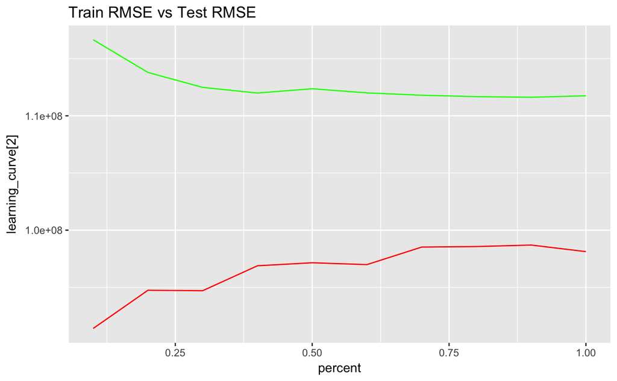

```r
# TODO: Build & evaluate model 1 (numeric variables only)
df2 <- df[sample(nrow(df)),]
test = df2[1: (dim(df2)[1] * 0.2),]
train = df2[((dim(df2)[1] * 0.2)) : dim(df2)[1],]
feature_set = c("Gross", "Runtime", "imdbVotes", "tomatoRating", "imdbRating","tomatoFresh","Budget" )
this_train = subset(train, select = feature_set)
this_train = na.omit(this_train)
this_test = subset(test, select = feature_set)
this_test = na.omit(this_test)
getLearningCurve <- function(train_rmse, test_rmse){

  learning_curve = matrix(c(0), nrow = 10, ncol = 3)
  colnames = c("sample_percentage", "train", "")
  for (row in 1: 10){
    learning_curve[row,1] = row * 0.1
    learning_curve[row, 2] = mean(train_rmse[row,])
    learning_curve[row, 3] = mean(test_rmse[row,])
  }
  learning_curve = data.frame(learning_curve)
  return(learning_curve)
}
plot_learning_curves <- function(learning_curve){
  percent = c(0.1, 0.2, 0.3, 0.4, 0.5, 0.6, 0.7, 0.8, 0.9, 1.0)
  g <- ggplot(learning_curve, aes(percent))
  g <- g + geom_line(aes(y=learning_curve[2]), colour="red")
  g <- g + geom_line(aes(y=learning_curve[3]), colour="green")
  g = g + labs(title = "Train RMSE vs Test RMSE")
return(g)
}
trainModel <- function(train, test){
  sample_size = as.integer(c(0.1, 0.2, 0.3, 0.4, 0.5, 0.6, 0.7, 0.8, 0.9, 1.0) * dim(train)[1])
  train_rmses = matrix(c(0), nrow = 10, ncol = 10)
  test_rmses = matrix(c(0), nrow = 10, ncol = 10)
  for (j in 1:10){
    train = train[sample(nrow(train)),]
    for (i in 1:10){
        cur = train[1:sample_size[i],]
        fit = lm(Gross~., data = cur, na.action = na.omit)
        cur$pred_train = predict(fit, cur)
        cur$resid = (cur$pred_train - cur$Gross) * (cur$pred_train - cur$Gross)
        cur_RMSE = sqrt(sum(cur$resid) / dim(cur)[1])
        train_rmses[i,j] = (cur_RMSE)
        test$pred_test = predict(fit, test)
        test$resid = (test$pred_test - test$Gross) * (test$pred_test - test$Gross)
        test_rmse = sqrt(sum(test$resid) / dim(test)[1])
        test_rmses[i, j] = test_rmse
    }
  }
  lc = getLearningCurve(train_rmses, test_rmses)
  return(lc)

}
lc_1 = trainModel(this_train, this_test)
g = plot_learning_curves(lc_1)
g
```

```r
head(lc_1, 10)
```

|  | X1 | X2 | X3 |
| --- | --- | --- | --- |
| 1 | 0.1 | 91408141 | 116648432 |
| 2 | 0.2 | 94747066 | 113791052 |
| 3 | 0.3 | 94708985 | 112483072 |
| 4 | 0.4 | 96887545 | 111989181 |
| 5 | 0.5 | 97152018 | 112365632 |
| 6 | 0.6 | 96989034 | 112003306 |
| 7 | 0.7 | 98522902 | 111797747 |
| 8 | 0.8 | 98568899 | 111675373 |
| 9 | 0.9 | 98700611 | 111618857 |
| 10 | 1.0 | 98124824 | 111750482 |

```r
print (min(lc_1[,3]))
```

```
[1] 111618857
```

```r
print (which.min(lc_1[,3]))
```

```
[1] 9
```

**Q**: List the numeric variables you used.

**A**: Gross, Runtime, imdbVotes, tomatoRating, imdbRating, tomatoFresh, Budget

## 2. Feature transformations

Try to improve the prediction quality from **Task 1** as much as possible by adding feature transformations of the numeric variables. Explore both numeric transformations such as power transforms and non-numeric transformations of the numeric variables like binning (e.g. `is_budget_greater_than_3M`).

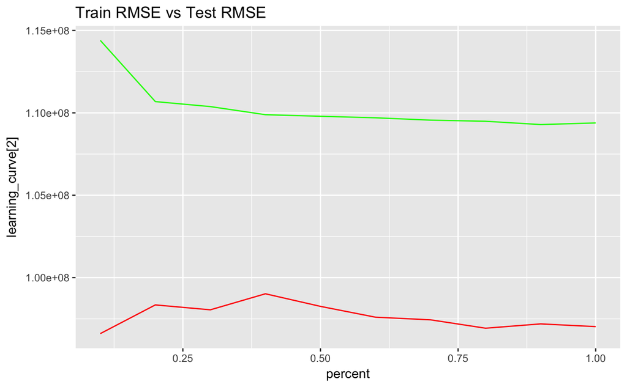

```r
# TODO: Build & evaluate model 2 (transformed numeric variables only)
selected = c("Gross", "Runtime", "imdbVotes", "tomatoRating", "imdbRating","tomatoFresh","Budget" )
train2 = subset(train, select = selected)
train2 = na.omit(train2)
train2$logBudget = log(train2$Budget)
train2$bintomatoRating = cut(train2$tomatoRating, 5, include.lowest=TRUE, labels=c(1, 2,3,4,5))
test2 = subset(test, select = selected)
test2 = na.omit(test2)
test2$logBudget = log(test2$Budget)
test2$bintomatoRating = cut(test2$tomatoRating, 5, include.lowest=TRUE, labels=c(1, 2,3,4,5))
lc_2 = trainModel(train2, test2)
g = plot_learning_curves(lc_2)
g
```

```r
head(lc_2, 10)
```

|  | X1 | X2 | X3 |
| --- | --- | --- | --- |
| 1 | 0.1 | 96603030 | 114398562 |
| 2 | 0.2 | 98346371 | 110683869 |
| 3 | 0.3 | 98048264 | 110380529 |
| 4 | 0.4 | 99020997 | 109888737 |
| 5 | 0.5 | 98256795 | 109792746 |
| 6 | 0.6 | 97599867 | 109700538 |
| 7 | 0.7 | 97440624 | 109557961 |
| 8 | 0.8 | 96931368 | 109489939 |
| 9 | 0.9 | 97194050 | 109289692 |
| 10 | 1.0 | 97028163 | 109388609 |

```r
print (min(lc_2[,3]))
```

```
[1] 109289692
```

```r
print (which.min(lc_2[,3]))
```

```
[1] 9
```

**Q**: Explain which transformations you used and why you chose them.

**A**: I used the log transformation to scale “budget” feature. I also “binned” tomatoRatings. Since, we want to improve prediction of “Gross” variable, we observed (in project 1) that log transforming “budget” variable has positive impact in predicting “Gross”. Binning tomato ratings help in differentiating tomato values even further. This increases the overall power of this feature.

## 3. Non-numeric variables

Write code that converts genre, actors, directors, and other categorical variables to columns that can be used for regression (e.g. binary columns as you did in Project 1). Also process variables such as awards into more useful columns (again, like you did in Project 1). Now use these converted columns only to build your next model.

```r
# TODO: Build & evaluate model 3 (converted non-numeric variables only)
selected = c("Gross", "Runtime", "imdbVotes", "tomatoRating","imdbRating","tomatoFresh","Budget", "Genre")
train3 = subset(train, select = selected)
train3 = na.omit(train3)
test3 = subset(test, select = selected)
test3 = na.omit(test3)
total = rbind(train3, test3)
library(tm)
myCorpus <- Corpus(VectorSource(total$Genre))
myTDM <- DocumentTermMatrix(myCorpus, control = list(minWordLength = 1))
x = as.matrix(myTDM)
total = cbind(total, x)
total$Genre = NULL
train3 = total[1: (dim(train3)[1]),]
test3 = total[(dim(train3)[1]): (dim(total)[1]),]
lc_3 = trainModel(train3, test3)
```

[output not shown]

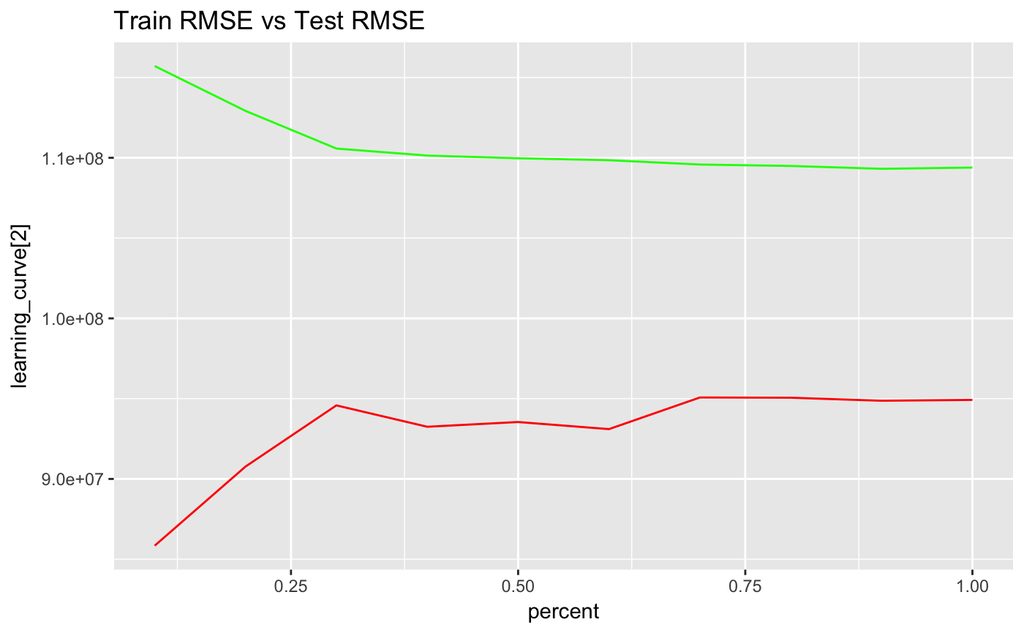

```r
g = plot_learning_curves(lc_3)
g
```

```r
print (min(lc_3[,3]))
```

```
[1] 109314710
```

```r
print (which.min(lc_3[,3]))
```

```
[1] 9
```

```r
head(lc_3, 10)
```

|  | X1 | X2 | X3 |
| --- | --- | --- | --- |
| 1 | 0.1 | 85843077 | 115714069 |
| 2 | 0.2 | 90772405 | 112920451 |
| 3 | 0.3 | 94581846 | 110576289 |
| 4 | 0.4 | 93249681 | 110138889 |
| 5 | 0.5 | 93545461 | 109970826 |
| 6 | 0.6 | 93103416 | 109850200 |
| 7 | 0.7 | 95072492 | 109580813 |
| 8 | 0.8 | 95058006 | 109492417 |
| 9 | 0.9 | 94870696 | 109314710 |
| 10 | 1.0 | 94923505 | 109390958 |

**Q**: Explain which categorical variables you used, and how you encoded them into features.

**A**: I used genre (categorical variable). Basically, I converted this feature into binary numbers (0/1). So, if movie belongs to a particular genre, the value is 1 else 0 (one hot encoding approach)

## 4. Numeric and categorical variables

Try to improve the prediction quality as much as possible by using both numeric and non-numeric variables from **Tasks 2 & 3**.

```r
# TODO: Build & evaluate model 4 (numeric & converted non-numeric variables)
library(tm)
selected = c("Gross", "Runtime", "imdbVotes", "tomatoRating","imdbRating","tomatoFresh","Budget", "Genre")
train4 = subset(train, select = selected)
train4 = na.omit(train4)
test4 = subset(test, select = selected)
test4 = na.omit(test4)
final = rbind(train4, test4)
corpus <- Corpus(VectorSource(final$Genre))
tdm <- DocumentTermMatrix(corpus, control = list(minWordLength = 1))
X = as.matrix(tdm)
final = cbind(final, X)
final$Genre = NULL
train4 = final[1: (dim(train4)[1]),]
test4 = final[(dim(train4)[1]): (dim(final)[1]),]
train4$logBudget = log(train4$Budget)
train4$bintomatoRating = cut(train4$tomatoRating, 5, include.lowest=TRUE, labels=c(1, 2,3,4,5))
test4$logBudget = log(test4$Budget)
test4$bintomatoRating = cut(test4$tomatoRating, 5, include.lowest=TRUE, labels=c(1, 2,3,4,5))
lc_4 <- trainModel(train4, test4)
```

[output not shown]

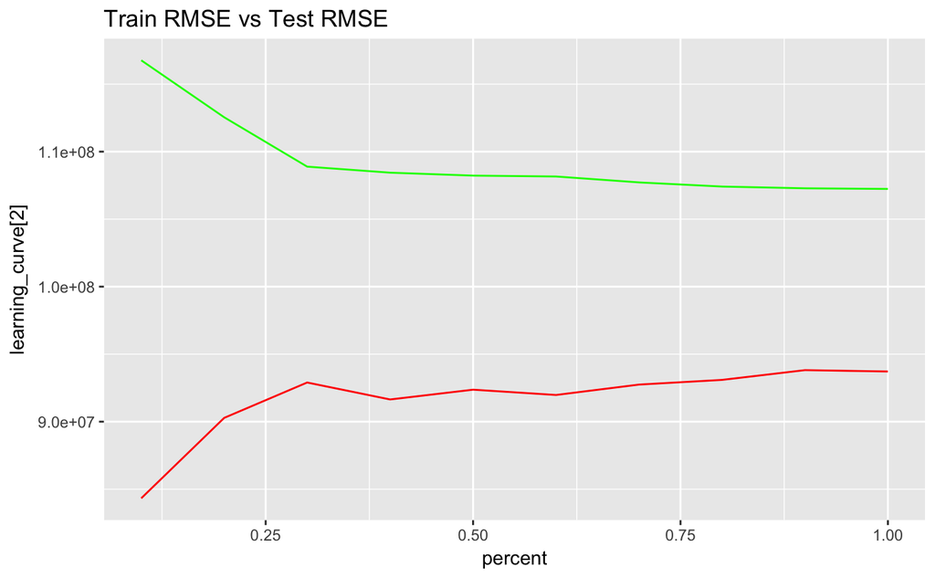

```r
g <- plot_learning_curves(lc_4)
g
```

```r
print (min(lc_4[,3]))
```

```
[1] 107238590
```

```r
print (which.min(lc_4[,3]))
```

```
[1] 10
```

```r
head(lc_4, 10)
```

|  | X1 | X2 | X3 |
| --- | --- | --- | --- |
| 1 | 0.1 | 84325668 | 116765995 |
| 2 | 0.2 | 90280997 | 112545484 |
| 3 | 0.3 | 92901187 | 108890405 |
| 4 | 0.4 | 91644969 | 108442594 |
| 5 | 0.5 | 92369753 | 108226359 |
| 6 | 0.6 | 91976981 | 108160607 |
| 7 | 0.7 | 92747534 | 107721742 |
| 8 | 0.8 | 93093939 | 107415780 |
| 9 | 0.9 | 93817339 | 107285578 |
| 10 | 1.0 | 93715892 | 107238590 |

## 5. Additional features

Now try creating additional features such as interactions (e.g. `is_genre_comedy` x `is_budget_greater_than_3M`) or deeper analysis of complex variables (e.g. text analysis of full-text columns like `Plot`).

```r
# TODO: Build & evaluate model 5 (numeric, non-numeric and additional features)
selected = c("Gross", "Runtime", "imdbVotes", "tomatoRating","imdbRating","tomatoFresh","Budget", "Genre")
train5 = subset(train, select = selected)
train5 = na.omit(train5)
test5 = subset(test, select = selected)
test5 = na.omit(test5)
final = rbind(train5, test5)
myCorpus <- Corpus(VectorSource(final$Genre))
myTDM <- DocumentTermMatrix(myCorpus, control = list(minWordLength = 1))
x = as.matrix(myTDM)
final = cbind(final, x)
final$Genre = NULL
train5 = final[1: (dim(train5)[1]),]
test5 = final[(dim(train5)[1]): (dim(final)[1]),]
train5$logBudget = log(train5$Budget)
train5$bintomatoRating = cut(train5$tomatoRating, 5, include.lowest=TRUE, labels=c(1, 2,3,4,5))
test5$logBudget = log(test5$Budget)
test5$bintomatoRating = cut(test5$tomatoRating, 5, include.lowest=TRUE, labels=c(1, 2,3,4,5))
train5$test <- ifelse(train5$imdbRating > 7 & train5$Budget > 5000000, 1, 0)
test5$test <- ifelse(test5$imdbRating > 7 & test5$Budget > 5000000, 1, 0)
lc_5 <- trainModel(train5, test5)
```

[output not shown]

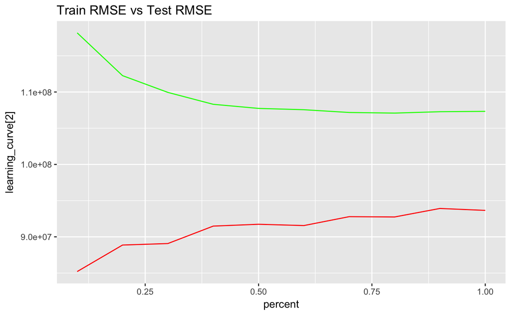

```r
g <- plot_learning_curves(lc_5)
g
```

```r
print (min(lc_5[,3]))
```

```
[1] 107089449
```

```r
print (which.min(lc_5[,3]))
```

```
[1] 8
```

```r
head(lc_5, 20)
```

|  | X1 | X2 | X3 |
| --- | --- | --- | --- |
| 1 | 0.1 | 85205803 | 118169122 |
| 2 | 0.2 | 88867088 | 112263126 |
| 3 | 0.3 | 89074596 | 109948595 |
| 4 | 0.4 | 91482865 | 108304503 |
| 5 | 0.5 | 91736500 | 107737064 |
| 6 | 0.6 | 91557064 | 107555285 |
| 7 | 0.7 | 92788908 | 107174326 |
| 8 | 0.8 | 92743262 | 107089449 |
| 9 | 0.9 | 93920541 | 107280058 |
| 10 | 1.0 | 93652407 | 107330229 |

**Q**: Explain what new features you designed and why you chose them.

**A**: I added a new binary feature. This binary feature indicates the current “perception” of movie based on imdbratings and budget of the movie. Basically, if the imdbrating is higher than 7 and the budget is greater than 5M, then feature would be 1. The reason to choose this is that this helps us in understanding the sentiment around the movie. Both budget and imdbRatings are known apriori which means that we can actually predict how much gross this movie would make before the movie is released. Note: while imdbRatings can accumulate forever but the rating process does start before movie is released.